# Vector Autoregression Analysis: Replication of Stock & Watson (2001)

## 6.6 Impulse Response Functions

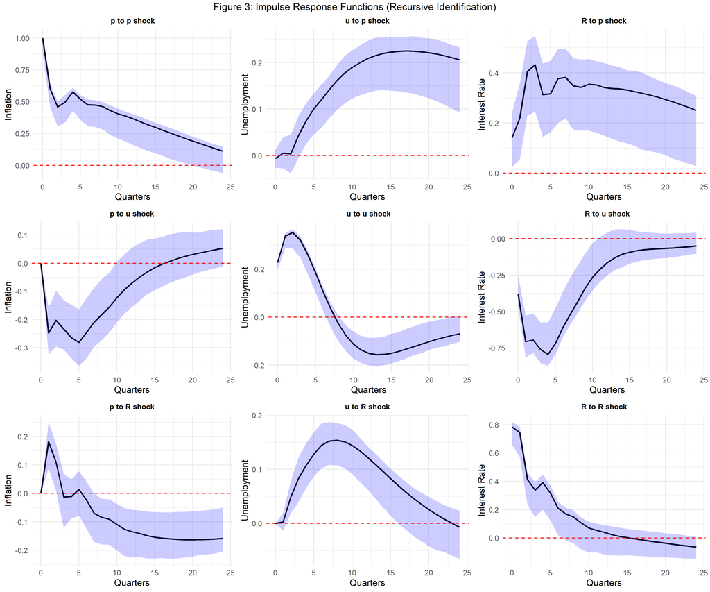

Figure 3: Impulse Responses

### 6.6.1 Interpretation

The impulse response functions trace out the dynamic effects of one-standard-deviation orthogonalized shocks. The shaded areas represent 68% bootstrap confidence intervals.

**Key Findings:** 1. Contractionary monetary policy (positive Fed Funds shock) creates short-run unemployment-inflation trade-off 2. Effects peak after 6-8 quarters, consistent with “long and variable lags” in monetary transmission 3. Confidence intervals widen at longer horizons, reflecting greater uncertainty 4. Results broadly consistent with New Keynesian DSGE models with sticky prices and gradual adjustment